# Applying Machine Learning Algorithms to Determine Credit-Worthiness

## Problem Statement

This project allows us to analyze a dataset with a binary response. The data comes from the CASdatasets library which is the dataset called credit. It contains 1,000 credit observations and 21 variables. The binary response variable class has values of 0 meaning credit-worthy, and 1 for not credit-worthy. So that means we will have to identify the important predictors of the remaining 20 variables by doing a descriptive analysis before applying different methods to predict the response variable.

## Learning the Data

```r
library(xts)
library(sp)
library(CASdatasets)
data(credit)
str(credit) #examine which variables are factors or continuous
```

```
## 'data.frame':    1000 obs. of  21 variables:
##  $ checking_status    : Factor w/ 4 levels "A11","A12","A13",..: 1 2 4 1 1 4 4 2 4 2 ...
##  $ duration           : int  6 48 12 42 24 36 24 36 12 30 ...
##  $ credit_history     : Factor w/ 5 levels "A30","A31","A32",..: 5 3 5 3 4 3 3 3 3 5 ...
##  $ purpose            : Factor w/ 10 levels "A40","A41","A410",..: 5 5 8 4 1 8 4 2 5 1 ...
##  $ credit_amount      : int  1169 5951 2096 7882 4870 9055 2835 6948 3059 5234 ...
##  $ savings            : Factor w/ 5 levels "A61","A62","A63",..: 5 1 1 1 1 5 3 1 4 1 ...
##  $ employment         : Factor w/ 5 levels "A71","A72","A73",..: 5 3 4 4 3 3 5 3 4 1 ...
##  $ installment_rate   : int  4 2 2 2 3 2 3 2 2 4 ...
##  $ personal_status    : Factor w/ 4 levels "A91","A92","A93",..: 3 2 3 3 3 3 3 3 1 4 ...
##  $ other_parties      : Factor w/ 3 levels "A101","A102",..: 1 1 1 3 1 1 1 1 1 1 ...
##  $ residence_since    : int  4 2 3 4 4 4 4 2 4 2 ...
##  $ property_magnitude : Factor w/ 4 levels "A121","A122",..: 1 1 1 2 4 4 2 3 1 3 ...
##  $ age                : int  67 22 49 45 53 35 53 35 61 28 ...
##  $ other_payment_plans: Factor w/ 3 levels "A141","A142",..: 3 3 3 3 3 3 3 3 3 3 ...
##  $ housing            : Factor w/ 3 levels "A151","A152",..: 2 2 2 3 3 3 2 1 2 2 ...
##  $ existing_credits   : int  2 1 1 1 2 1 1 1 1 2 ...
##  $ job                : Factor w/ 4 levels "A171","A172",..: 3 3 2 3 3 2 3 4 2 4 ...
##  $ num_dependents     : int  1 1 2 2 2 2 1 1 1 1 ...
##  $ telephone          : Factor w/ 2 levels "A191","A192": 2 1 1 1 1 2 1 2 1 1 ...
##  $ foreign_worker     : Factor w/ 2 levels "A201","A202": 1 1 1 1 1 1 1 1 1 1 ...
##  $ class              : num  0 1 0 0 1 0 0 0 0 1 ...
```

Another step I took in the data cleaning process was to turn four of the categorical variables into numeric rankings. This is because when I studied each of the predictors, these four variables would be more interpretable as numeric variables. For example, checking_status is a factor with 4 levels as you can see below. I changed A11 as 1, A12 as 2, A13 as 3, and A14 as 0 because that means the individual doesn’t have an existing checking account. I did similar rankings with savings, employment, and telephone.

```r
#checking_status: status of existing checking account (4 levels)
credit$checking_status <- as.numeric(credit$checking_status)
credit$checking_status <- ifelse(credit$checking_status==4,0,credit$checking_status) #set no checking account equal to 0
#savings: status of existing checking account (5 levels)
credit$savings <- as.numeric(credit$savings)
credit$savings <- ifelse(credit$savings==5,0,credit$savings) #set no savings account to 0
#employment: present employment since (5 levels)
credit$employment <- as.numeric(credit$employment)
#telephone: has telephone or not (2 levels)
credit$telephone <- as.numeric(credit$telephone)
credit$telephone <- ifelse(credit$telephone==2,0,credit$telephone) #set no telephone to 0
#convert dataset into dataframe and attach
credit <- data.frame(credit)
attach(credit)
```

After the data cleaning process I applied descriptive analysis to explore the data. First, I wanted to examine the correlation coefficients between each of the numeric variables and the response variable class.

```r
cor(credit[,c(1,2,6,7,8,11,13,16,18,19,21)])[,"class"]
```

```
##  checking_status         duration          savings       employment
##      0.197787636      0.214926665     -0.033871266     -0.116002036
## installment_rate  residence_since              age existing_credits
##      0.072403937      0.002967159     -0.091127409     -0.045732489
##   num_dependents        telephone            class
##     -0.003014853      0.036466190      1.000000000
```

Notice that duration, checking_status, employment, and age have the highest correlation coefficients ranging from |-0.09| to 0.22. Even though the coefficients aren’t high, they show that there is some linear relationship between these variables and class. To visualize this, I plotted boxplots for these four variables.

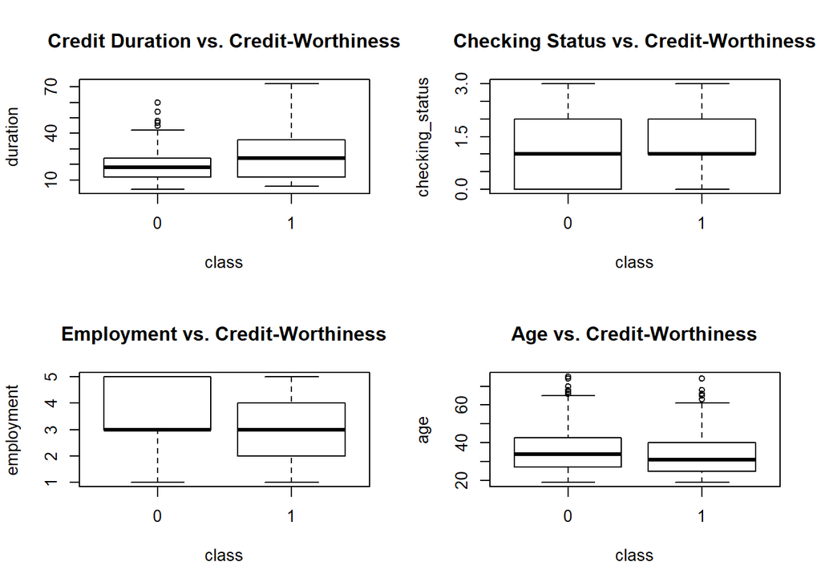

```r
par(mfrow=c(2,2))
boxplot(duration~class,main="Credit Duration vs. Credit-Worthiness")
boxplot(checking_status~class,main="Checking Status vs. Credit-Worthiness")
boxplot(employment~class,main="Employment vs. Credit-Worthiness")
boxplot(age~class,main="Age vs. Credit-Worthiness")
```

The “Credit Duration vs. Credit-Worthiness” boxplot shows that typically, those who are not credit-worthy (class 1) have higher credit duration in months. Although, there are some individuals who are credit-worthy (class 0) who have high credit duration and are considered outliers. The next two plots shows that class 0 and class 1 both have equal medians as you can see with the thick black lines being at the same level. The last plot shows that typically, those who are credit-worthy are older on average.

The amount that one asks for when trying to open a credit line seems very important when determining who is credit-worthy and who’s not. So, I wanted to examine the descriptive statistics of the continuous variable credit_amount.

```r
data.frame("Mean"=mean(credit_amount),"Variance"=var(credit_amount),"Median"=median(credit_amount))
```

```
##       Mean Variance Median
## 1 3271.258  7967843 2319.5
```

On average, individuals request about 3,271 in Deutsch marks. Also, notice that the variance is very large at 7,967,843. Meaning, there are a lot of individuals who request a credit amount way higher than 3,271. Here is a boxplot showing those outliers in both class 0 and class 1.

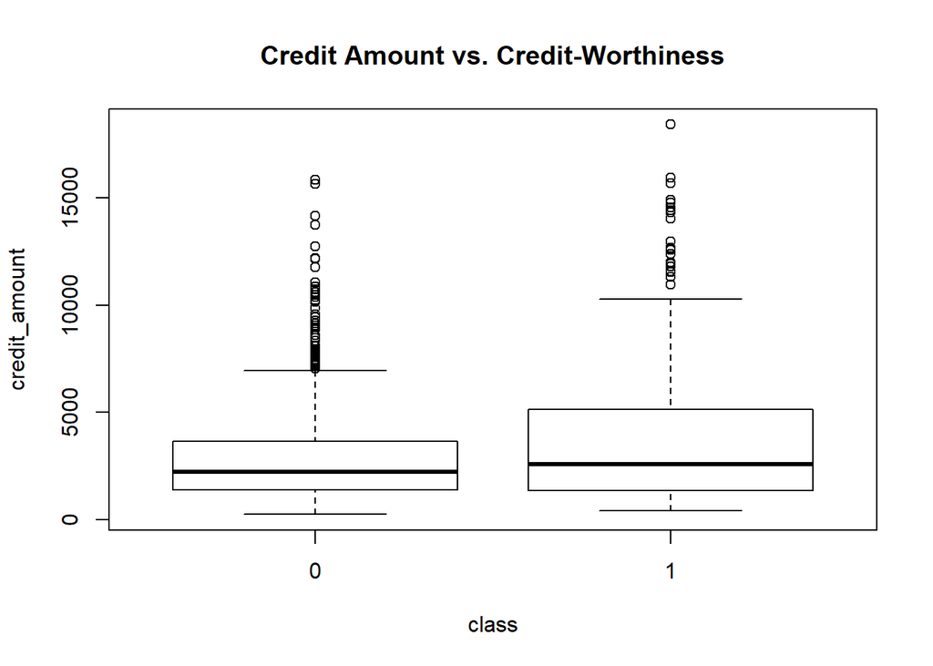

```r
boxplot(credit_amount~class,main="Credit Amount vs. Credit-Worthiness")
```

I also wanted to examine some of the categorical variables that seemed important based on their context. I plotted barplots of the predictors credit_history, purpose, personal_status, and job to view their distribution among each class.

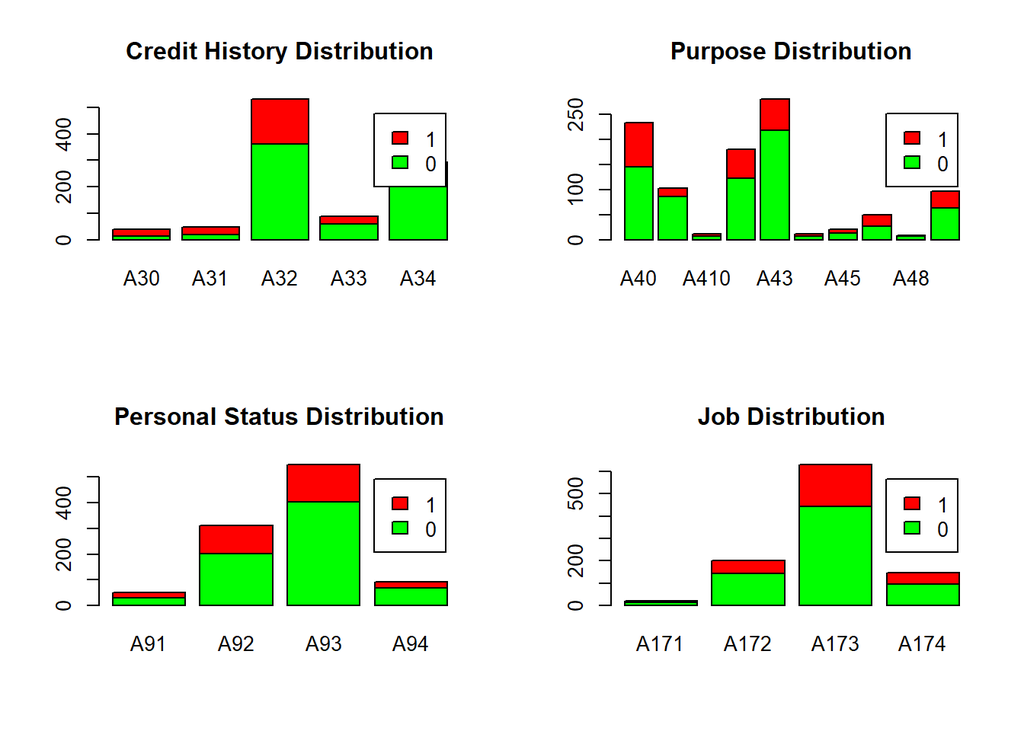

```r
par(mfrow=c(2,2))
barplot(table(class,credit_history),main="Credit History Distribution",
        legend=rownames(table(class,credit_history)),col=c("green","red"))
barplot(table(class,purpose),main="Purpose Distribution",
        legend=rownames(table(class,credit_history)),col=c("green","red"))
barplot(table(class,personal_status),main="Personal Status Distribution",
        legend=rownames(table(class,personal_status)),col=c("green","red"))
barplot(table(class,job),main="Job Distribution",
        legend=rownames(table(class,job)),col=c("green","red"))
```

When you look at the credit history distribution graph, you can see that most of the credit-worthy individuals are in category A32 (no credits taken or all credits paid back duly). Obviously, that makes sense and also there are more class 1 individuals (not credit-worthy) in categories A30 (delay in paying off in the past) and A31 (critical account). Also, most individual’s purpose of credit is A43 (radio/television) with most being credit-worthy. Most non credit-worthy individuals borrow for the purpose of A40 (new car). The third graph shows that most borrowers are male and single and are mostly credit-worthy. The final graph shows that most credit-worthy individuals are categorized in the A173 class (skilled worker/skilled employee/minor civil servant).

## Splitting the Data

After examining the predictors, next step is to spit the data into a training set to train our models and a test set to test the trained models. For this analysis, I will split 70% as the training data and 30% as the test data by running a random sample.

```r
set.seed(1) #set seed
train = sample(1:nrow(credit), .7*nrow(credit)) #training sample
test = setdiff(1:nrow(credit), train) #test sample
credit.train = credit[train,] #training dataset
credit.test = credit[-train,] #test dataset
class.train = credit[train,"class"] #class values from training dataset
class.test = credit[-train,"class"] #class values from test dataset
```

## Logistic Regression

This first model I will use logistic regression on the training dataset using all predictors.

```r
library(glmnet)
glm.fit = glm(class~.,family=binomial,data=credit.train) #logisitic regression model
summary(glm.fit)
```

```
##
## Call:
## glm(formula = class ~ ., family = binomial, data = credit.train)
##
## Deviance Residuals:
##     Min       1Q   Median       3Q      Max
## -2.8421  -0.7481  -0.4405   0.8290   2.3588
##
## Coefficients:
##                           Estimate Std. Error z value Pr(>|z|)
## (Intercept)             -1.310e+00  1.274e+00  -1.028 0.303752
## checking_status          3.551e-01  1.027e-01   3.459 0.000543 ***
## duration                 2.980e-02  1.098e-02   2.715 0.006622 **
## credit_historyA31       -7.006e-02  6.117e-01  -0.115 0.908814
## credit_historyA32       -8.821e-01  4.685e-01  -1.883 0.059716 .
## credit_historyA33       -9.976e-01  5.081e-01  -1.963 0.049609 *
## credit_historyA34       -1.646e+00  4.824e-01  -3.412 0.000644 ***
## purposeA41              -1.516e+00  4.197e-01  -3.612 0.000304 ***
## purposeA410             -2.202e+00  1.134e+00  -1.941 0.052260 .
## purposeA42              -3.073e-01  2.955e-01  -1.040 0.298359
## purposeA43              -9.792e-01  2.817e-01  -3.477 0.000508 ***
## purposeA44              -3.706e-01  8.850e-01  -0.419 0.675381
## purposeA45              -3.544e-01  6.398e-01  -0.554 0.579632
## purposeA46              -2.176e-01  4.666e-01  -0.466 0.640968
## purposeA48              -1.496e+01  5.202e+02  -0.029 0.977058
## purposeA49              -6.556e-01  3.788e-01  -1.731 0.083521 .
## credit_amount            9.226e-05  5.319e-05   1.735 0.082821 .
## savings                 -8.005e-02  1.097e-01  -0.730 0.465504
## employment              -2.189e-01  9.247e-02  -2.367 0.017919 *
## installment_rate         3.370e-01  1.038e-01   3.248 0.001164 **
## personal_statusA92      -1.462e-01  4.452e-01  -0.328 0.742616
## personal_statusA93      -6.129e-01  4.406e-01  -1.391 0.164211
## personal_statusA94      -5.183e-01  5.537e-01  -0.936 0.349210
## other_partiesA102        6.679e-01  5.206e-01   1.283 0.199530
## other_partiesA103       -2.837e-02  4.958e-01  -0.057 0.954363
## residence_since         -6.247e-02  1.002e-01  -0.624 0.532781
## property_magnitudeA122   2.413e-01  2.936e-01   0.822 0.411058
## property_magnitudeA123   2.657e-01  2.733e-01   0.972 0.330864
## property_magnitudeA124   1.186e+00  5.153e-01   2.302 0.021327 *
## age                     -2.011e-02  1.027e-02  -1.957 0.050289 .
## other_payment_plansA142 -2.535e-01  4.506e-01  -0.563 0.573755
## other_payment_plansA143 -6.691e-01  2.705e-01  -2.473 0.013387 *
## housingA152             -6.813e-01  2.718e-01  -2.507 0.012183 *
## housingA153             -7.120e-01  5.672e-01  -1.255 0.209363
## existing_credits         3.304e-01  2.140e-01   1.544 0.122619
## jobA172                  1.576e+00  8.134e-01   1.937 0.052743 .
## jobA173                  1.555e+00  7.937e-01   1.960 0.050054 .
## jobA174                  1.522e+00  8.341e-01   1.825 0.067992 .
## num_dependents           2.693e-01  2.892e-01   0.931 0.351787
## telephone                4.194e-01  2.264e-01   1.852 0.063977 .
## foreign_workerA202      -2.062e+00  8.435e-01  -2.444 0.014508 *
## ---
## Signif. codes:  0 '***' 0.001 '**' 0.01 '*' 0.05 '.' 0.1 ' ' 1
##
## (Dispersion parameter for binomial family taken to be 1)
##
##     Null deviance: 851.79  on 699  degrees of freedom
## Residual deviance: 668.95  on 659  degrees of freedom
## AIC: 750.95
##
## Number of Fisher Scoring iterations: 14
```

```r
glm.probs = predict(glm.fit,newdata=credit.test,type="response") #returns probabilities
glm.pred = rep(0,length(glm.probs))
glm.pred[glm.probs>0.6] = 1 #chosen cutoff point: 0.6
mean((glm.pred-class.test)^2) #MSE
```

```
## [1] 0.2566667
```

```r
table(glm.pred,class.test) #confusion matrix
```

```
##         class.test
## glm.pred   0   1
##        0 193  62
##        1  15  30
```

```r
logreg_pa <- (193+30)/300 #prediction accuracy rate
```

The summary shows which predictors are significant according to this model by their p-value. Notice that checking_status, credit_historyA34, purposeA41, and purposeA43, are all very significant. I chose a cutoff point of 0.6 meaning if the returned probabilites given from the predict function is greater than 0.6, than classify that record as class 1. This gives a MSE of 0.2566667 or a 74.33% prediction accuracy rate. Also, when I ran the same model with just the predictors that are important checking_status, credit_history, and purpose, it actually gave a lower prediction accuracy so that’s why I chose to stick with the original model using all predictors.

## Logistic Regression with LASSO

The next method I used is logistic regression with LASSO. Since p=20 (the number of predictors) is fairly large, LASSO is a reasonable method to use to shrink the coefficient estimates towards 0. LASSO performs variable selection and results in a model that is easier to interpret.

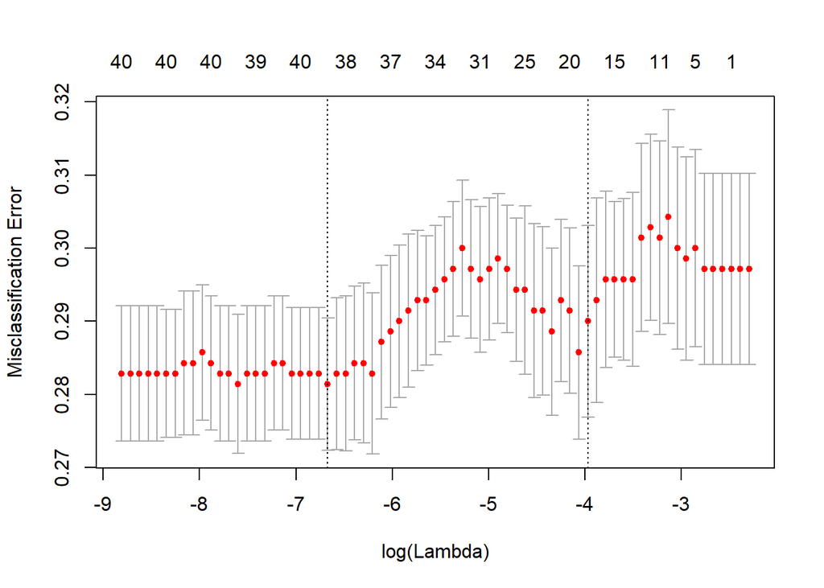

```r
set.seed(2)
train.matrix = model.matrix(class~.,data=credit.train) #design matrix for training dataset
test.matrix = model.matrix(class~.,data=credit.test) #design matrix for test dataset
grid = 10^seq(10,-2,length=100)
cv.out = cv.glmnet(train.matrix,class.train,alpha=1,family="binomial",type.measure="class",nfolds=10) #10-fold CV
plot(cv.out)
```

```r
out = glmnet(train.matrix,class.train,alpha=1,lambda=grid,family="binomial") #LASSO model
bestlam.lasso = cv.out$lambda.min #best lambda based on cross validation
bestlam.lasso
```

```
## [1] 0.00126789
```

```r
lasso.prob=predict(out,test.matrix,s=bestlam.lasso)
lasso.pred = rep(0,300)
lasso.pred[lasso.prob>0.9]=1 #chosen cutoff point: 0.9
table(lasso.pred, class.test) #confusion matrix
```

```
##           class.test
## lasso.pred   0   1
##          0 205  87
##          1   3   5
```

```r
logreg_lasso_pa <- (205+5)/300 #prediction accuracy rate
```

By using cross-validation to choose the tuning parameter λ, you can see from the plot that log(λ=0.00126789) = -6.670401 gives the lowest misclassification error. With a chosen cutoff point of 0.9, the prediction accuracy is 70% which is lower than the one calculated from just logistic regression. When I change the cutoff point, the prediction accuracy doesn’t change that is why I chose a higher cutoff point that 0.5.

## Decision Tree with Pruning

A classification tree is used for a qualitative response. Even though our response is technically numeric, it’s binary so it acts as a qualitative variable with 0 meaning credit-worthy and 1 meaning not credit-worthy. A classification tree assigns an observation in a given region to the most commonly occurring class of observations in that region.

```r
library(tree)
credit$class <- as.factor(credit$class) #change response from numeric to factor variable
credit.tree = tree(class~.,credit) #Establish a tree for the response variable class
summary(credit.tree)
```

```
##
## Classification tree:
## tree(formula = class ~ ., data = credit)
## Variables actually used in tree construction:
## [1] "checking_status"     "other_payment_plans" "credit_history"
## [4] "duration"            "purpose"
## Number of terminal nodes:  7
## Residual mean deviance:  1.022 = 1015 / 993
## Misclassification error rate: 0.267 = 267 / 1000
```

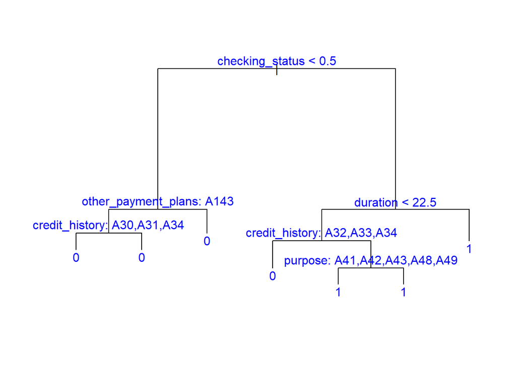

```r
plot(credit.tree) #Plot the decision tree
text(credit.tree, pretty=0, col="blue") #Add the labels for the nodes in the tree
```

From the information given by the summary command, the number of terminal nodes used is 7 and the misclassification error is 0.267 or a prediction accuracy rate of 73.3% This is higher than the logistic regression with LASSO model but lower than just the logistic regression model.

Next, I examined the prediction accuracy of the decision tree using cross validation using the subset as the training sample.

```r
credit.tree = tree(class~.,credit,subset=train) #Obtain the tree based on training set
tree.pred = predict(credit.tree,credit.test,type="class") #Get the prediction on the test set
table(tree.pred,class.test) #confusion matrix
```

```
##          class.test
## tree.pred   0   1
##         0 167  57
##         1  41  35
```

```r
dt_pa <- (167+35)/300 #prediction accuracy rate
```

The confusion matrix shows a prediction accuracy rate lowest of all at 67.33%. So this model is probably not the best in accurately predicting credit-worthiness. Another good strategy is to grow a large tree and prune it to obtain an optimal subtree, hopefully increasing the prediction accuracy rate. Below is the pruning procedure.

```r
set.seed(2)
cv.credit = cv.tree(credit.tree,FUN=prune.misclass)
cv.credit
```

```
## $size
## [1] 12 11  8  6  5  1
##
## $dev
## [1] 212 212 206 210 218 210
##
## $k
## [1]     -Inf 0.000000 2.333333 4.500000 7.000000 9.000000
##
## $method
## [1] "misclass"
##
## attr(,"class")
## [1] "prune"         "tree.sequence"
```

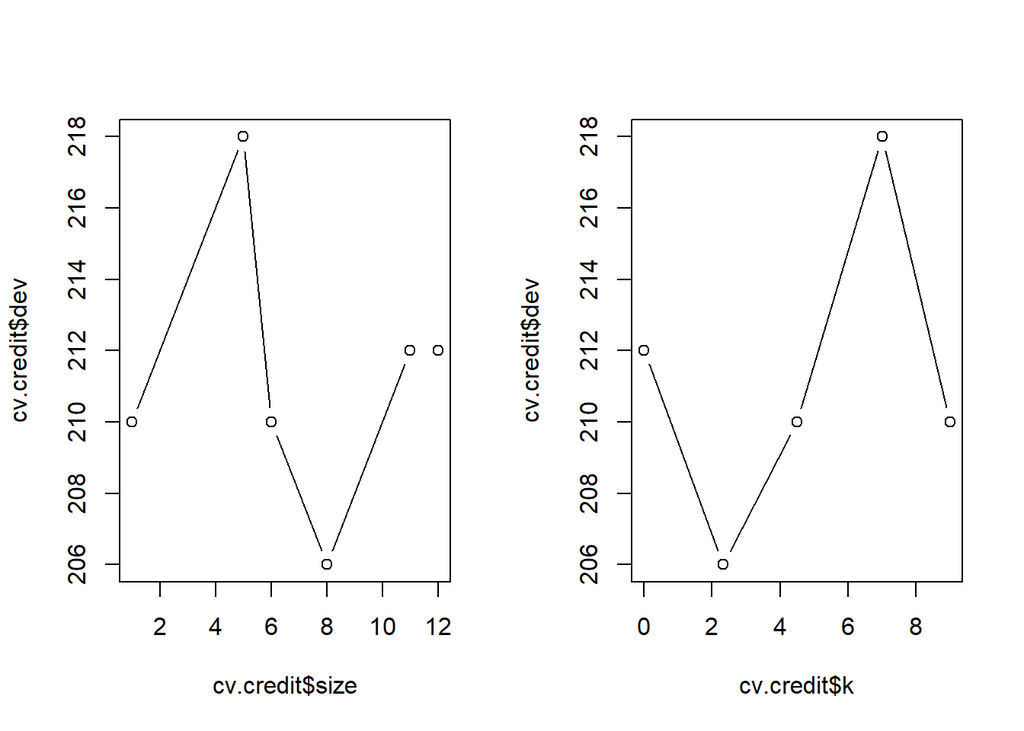

```r
par(mfrow=c(1,2))
plot(cv.credit$size,cv.credit$dev,type="b") #looks like size with minimum deviance is 8
plot(cv.credit$k,cv.credit$dev,type="b")
```